Non-target sequence screen · BIOL7800 · 22 Oct 2026

# *Toxocara canis*: what else is in the reads

The genome readset (2014 adult worms) and the 6 adult RNA-seq samples (Kansas 2023) are fully screened. Every detection below was confirmed by mapping, not just by a classifier hit.

DNA: **SRR1706691** · PRJNA248777 · assembly GCA_000803305.1 RNA: **6 adults** · PRJNA1041894 · NextSeq 2×73 bp · poly-A All RNA runs on one flowcell: **H5VV2BGXT**

## Significance bins

noiseNot credible as an organism: classifier or database artefact.

traceReal, but too little to change any analysis.

consequentialLarge enough to change an analysis, or already inside the reference.

biologicalA real associate worth reporting in its own right.

## Genome readset · SRR1706691 + published assembly

Reads that didn't map to the assembly, or mapped to flagged contigs (968,828 pairs, 1.8%), were mapped competitively against worm, dog, human and microbes. ppm = per million of 54.9 M read pairs.

[output not shown]

## Genome blobplot

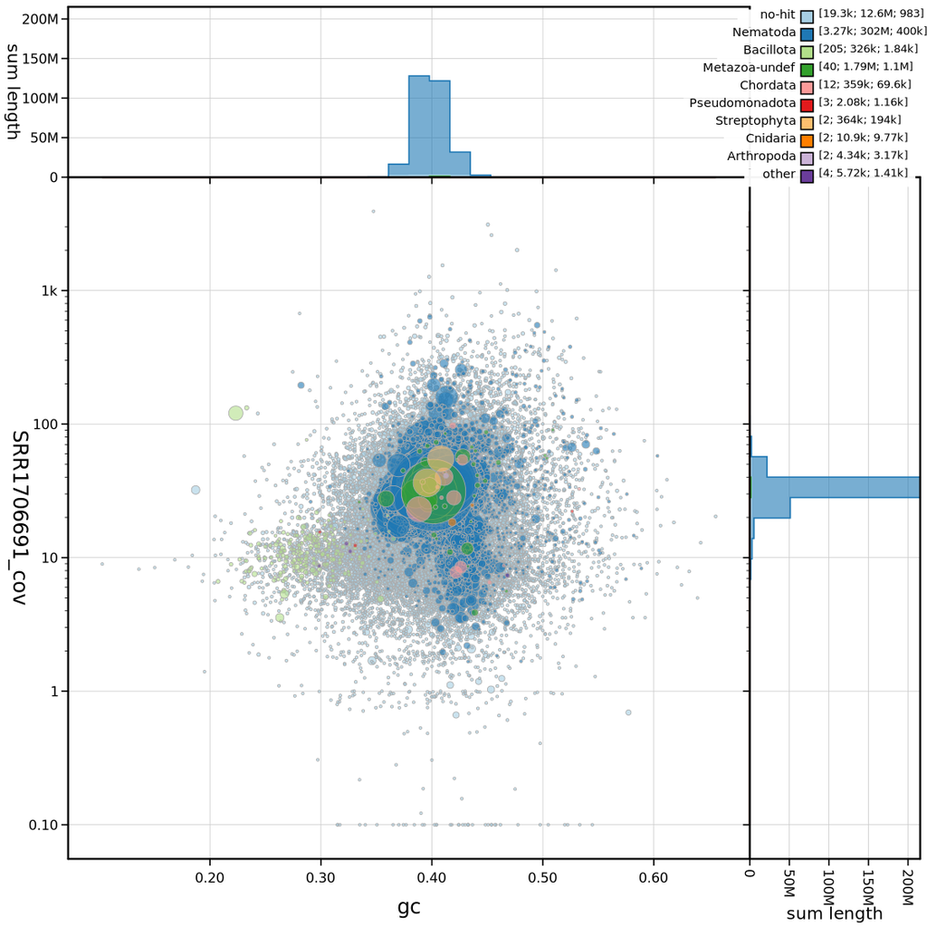

GC content (x) against coverage from SRR1706691 (y). Each circle is a contig, sized by length and coloured by best protein hit (UniRef50).

- **Nematoda**: 3,270 contigs, 302 Mb. The worm cloud sits near 40% GC and 32× coverage.

- **Bacillota**: 205 contigs, 326 kb. A separate cloud at 28% GC and 11× coverage: *C. perfringens*.

- **The far-left outlier** at 22% GC and 121× is the *C. perfringens* plasmid.

- **Chordata, Streptophyta, Metazoa-undef** sit inside the worm cloud at worm coverage. These are conserved worm genes given a broad label, not contamination; the dog alignment found no dog sequence.

- **No-hit**: 19,300 tiny contigs (N50 983 bp), spread through the worm cloud.

## RNA viruses in the 6 adult worms

Reads at mapping quality ≥20 on each virus. Green = real infection, because the sample carries its own variant. Grey = bleed-through from another worm on the same flowcell, because its reads carry that worm's variant. The virus references (Liverpool School of Tropical Medicine, 2024) were assembled from *2014* data (SRR1707010 and others), so these detections are independent of it.

| Virus | F_T1 | F_T2 | F_T3 | M_T10 | M_T4 | M_T6 | Bin |
| --- | --- | --- | --- | --- | --- | --- | --- |
| TcLA ("larvae agent")Jingmen-like, segmented; 3 segments (2 new) | 6 | 244 | 344 | 2,691 | 4.34 M~7% of pairs | 5.59 M~9% of pairs | biological consequential |
| RV1totivirus-like, 7.7 kb | 17,78495% · 160× | 10 | 74 | 16,64899.6% · 150× | 58 | 6,340divergent strain (4.6%) | biological |
| RV2totivirus-like, 7.6 kb | 0 | 18 (?) | 2,02490% · 18× | 0 | 0 | 0 | biological |
| RV3 | 0 | 1 | 13 | 0 | 1,05592–96% | 1,735divergent (84%) | biological |
| RV4-like + new toti-like contig | 0 | 234own strain | ≤4 | 0 | 1,223own strain | 2,986own strain | biological |

**Why the bleed-through calls are firm:** M_T10's 1,149 TcLA segment-1 reads cover 96% of the segment, which would look like an infection on breadth alone. But at diagnostic sites they carry M_T6's alleles (60 bases) plus M_T4's (9). A worm's own infection wouldn't be a mixture of two other worms' viruses. The bleed-through rate works out to about 0.07–0.2% of the source sample's reads.

**Database error:** TcLA segment proteins match *T. canis* "antigens" ANT-5, ANT-30 and ANT-34 in UniProt at 98.6–99.7%. Those larval "antigens" appear to be viral proteins.

## Other detections in the adult RNA

Split competitive mapping of non-worm reads against worm (+ mitochondrion) / microbes / dog / human; each pair goes to the best target by ≥10 score points. ppm = per million trimmed read pairs.

| Detection | F_T1 | F_T2 | F_T3 | M_T10 | M_T4 | M_T6 | Bin | Source & evidence |
| --- | --- | --- | --- | --- | --- | --- | --- | --- |
| *Herbaspirillum* sp. | 29 | 78 | 21 | 159 | 193 | 14 | trace | **Reagent.** Known kit contaminant; about 84% identity to any reference genome. Rises and falls with *Delftia*, *Leifsonia* and *Ralstonia*; absent from the 2014 DNA. |
| *Delftia acidovorans* | 3.6 | 5.9 | 2.3 | 41 | 63 | 1.5 | trace | **Reagent.** Same pattern as above. |
| *Leifsonia* sp. | 5.4 | 12 | 3.9 | 64 | 39 | 1.9 | trace | **Reagent.** |
| *Ralstonia* | 2.1 | 5.9 | 0.8 | 8.6 | 13 | 3.3 | trace | **Reagent.** |
| Human | 19 | 26 | 8.6 | 45 | 68 | 8.0 | trace | **Human handling.** Spread over 183–687 loci; travels with skin microbes (*Cutibacterium*, *S. epidermidis*, *Malassezia*). Higher than dog in every worm. |
| Dog | 5.5 | 0.5 | 0.2 | 2.0 | 11 | 1.5 | trace | **Host carry-over.** Small, so the worms were well washed. |
| *Enterococcus* (avium group) | 2.7 | — | — | — | 27 | — | trace | **Probable gut associate.** Only in some worms; about 92% identity to known species. |
| *Collinsella* | 1.2 | 1.4 | 0.5 | 14 | 3.7 | 0.3 | trace | **Probable gut associate.** |
| Bacterial 23S rRNA ("*Heyndrickxia*") | — | — | — | 100 | 2.2 | — | trace | **Gut or diet, unconfirmed.** Reads pile on 2 rRNA contigs (8 kb of 3 Mb; observed/expected breadth 0.02). Real bacterial RNA, but the genus call is weak. |
| *C. perfringens* | 0.7 | — | — | — | 0.03 | 0.3 | noise | Barely present in these worms; the strong signal is in the 2014 DNA. |

## Classifier hits that were not real

| Hit | Where | Bin | Source | What it actually was |
| --- | --- | --- | --- | --- |
| *Thalassiosira pseudonana* (diatom) | Females only (87–110 reads) | noise | Database error | All reads stack on one 80 bp locus: worm **polyubiquitin** (BLAST: 88–92% to ubiquitin from clam, plants, insects). A female-biased worm transcript missing from the assembly. |
| Cloning vector pRNA8 | Females (sendsketch) | noise | Database error | The vector carries a whole *E. coli* rRNA operon. All 914 mapped reads fall on 16S/23S rRNA, none on the vector genes. Bacterial rRNA reads, not vector. |
| *Salmonella* (~4 kb references) | F_T1, F_T2 | noise | Database error | Likely the same rRNA-entry artefact; not separately confirmed by mapping. |
| *Goezia pelagia* (fish nematode) | 3 samples | noise | Worm itself | 99% identity to a short roundworm rRNA entry: *T. canis* rRNA. |
| Contigs labelled "Chordata" / "Streptophyta" | Assembly | noise | Database error | Worm GC, worm coverage, no dog alignment: conserved worm genes given a broad UniRef50 label. |

## Non-worm fraction per adult

|  | F_T1 | F_T2 | F_T3 | M_T10 | M_T4 | M_T6 |
| --- | --- | --- | --- | --- | --- | --- |
| Trimmed pairs | 26.6 M | 27.6 M | 28.9 M | 25.8 M | 30.1 M | 29.7 M |
| Not mapping to worm (HISAT2) | 8.2% | 8.8% | 7.3% | 12.6% | 14.4% | 20.0% |

Most of the non-worm pool is still worm: 30% maps to worm with minimap2, including the mitochondrion, which is only half present in the assembly. Much of the rest matches roundworms (sendsketch). The males' extra fraction is mostly TcLA in M_T4 and M_T6.

## Scope and limitations

- RNA-seq: the 6 adult worms of PRJNA1041894 were screened; the 9 larval samples in the same BioProject were not.
- The optional spike-in detection-limit test was not run.